# Transfer Function Noise Modeling

Jen-Wen Lin, PhD, CFA

2020-11-06

### Instructions

##### 1. Download delinquency rates[^1] and real GDP data from Quercus and put them into your working directory.

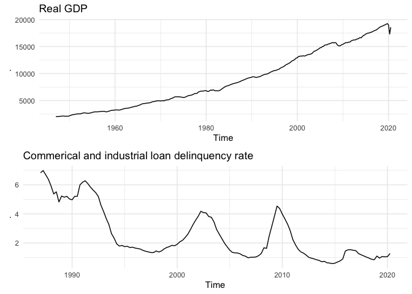

##### 2. Calculate the changes of real GDP using the following R codes.

```r
dat = read.csv("GDPC1.csv")
RGDP = ts(diff(dat[,2])/100,frequency = 4, end = c(2020,3))
```

##### Use the data between 1987 Q1 and 2018 Q3 to study the relationship between the changes of real GDP and delinquency rates.

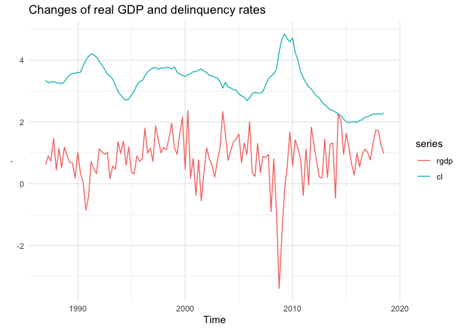

##### Model this relationship using the transfer function noise model.(For simplicity, assume that both delinquency rates and changes of real GDP are stationary.)

Your analyses should include:

1. Conduct `prewhitening` analysis to identify the lead-lag relationship between changes of real GDP and delinquency rates;
2. Fit a multiple regression using the findings in the `prewhitening` step, i.e.
   $$y_t = \sum_i v_i x_{t-i} +\xi_t,$$
   where $y_t$ and $x_t$ denote the output and input process, respectively, and $\xi_t$ is the noise process.(Hint: Use `prewhitening` to select the lagged $\{x_i\}$ in the regression)
3. Fit a transfer function noise model using the rational distributed lag function, i.e.
   $$y_t = \frac{\delta(B)}{\omega(B)}x_t+n_t,$$
   where $\delta(B)$ and $\omega(B)$ are polynomials in the backward shift operator $B$, and $n_t$ follows an ARMA process. Write down the mathematical representation of the fitted model.
4. Conduct the model adequacy tests (diagnostics) on the above models and conclude your inference.

##### 3. Conduct the out of sample forecasts of the above fitted models using the remaining observations. Calculate the forecast performance using Mean squared error (MSE), Mean absolute error (MAE), and Mean absolute percentage error (MAPE):

$$MSE = \sqrt \frac{\sum_{i=1}^L (y_{t+i}-\hat y_t(i))^2}{L}$$
$$MAE = \frac{\sum_{i=1}^L \left|y_{t+i}-\hat y_t(i)\right|}{L}$$
$$MAPE = \frac{1}{L}\sum_{i=1}^L \left|1-\frac{\hat y_t(i)}{y_{t+i}}\right|,$$
where $\hat y_t(i)$ denotes the forecast at origin $t$ with lead time $i$

##### 4. Conduct the same out of sample forecasts soley on $y_t$ using an ARIMA model. Compare and discuss its peformance metrics with the TFN model.

- **Hint:** You may fit an ARIMA model on $y_t$ using `auto.arima` but ensure that the fitted model pass the Ljung-Box test.

##### 5. Conduct the same out of sample forecast analysis using forecast combination of the fitted TFN model and ARIMA model (equal weight and MSE weighting). Compare its forecast metrics with those in the previous two questions

- *Forecast combination:*
  The combined forecaster $\hat f_t(i)$ may be given by
  $$\hat f_t(i) = w_a ~ \hat y_t^{(a)}(i)+w_b~ \hat y_t^{(b)}(i),$$
  where the superscripts $(a)$ and $(b)$ stand for transfer function noise model and ARIMA model, respectively. For the equal weight scheme, $w_a = w_b = 0.5$, and for the MSE weighting scheme, its weights is the solution of
  $$\min_{w_a} \sqrt {\sum_{t=1}^n \{y_t -w_a \hat y_t^{(a)}-(1-w_a)\hat y_t^{(b)}\}^2},$$
  where $w_a, w_b \in[0,1]$, $w_a+w_b=1$, and $\hat y_t^{(a)}$ denote the fitted value at time $t$ in the training sample and $n$ is the series length.
- **Reference:** William W.S. Wei (2006), *Time Series Analysis–Univariate and Multivariate Methods*, Second Edition. (Chapter 14)
[^1]: Delinquency rates on Commercial and Industrial Loans, Top 100 Banks Ranked by Assets.